# Modeling and prediction for movies

## Setup

### Load packages

```r
library(ggplot2) # data visualization
library(dplyr)   # data manipulation
library(gridExtra) # multiple plots in one graph

# apply general knitr options
knitr::opts_chunk$set(comment=NA, fig.align='center')
```

## Part 1: Data

The movies dataset is comprised of 651 randomly sampled movies produced and release before 2016. The dataset includes information from [Rotten Tomatoes](https://www.rottentomatoes.com/) and [IMDB](http://www.imdb.com/). Since the movies dataset is randomly sampled, statistical conclusion drawn from this dataset can be generalize to all movies produced and released before 2016. However, movie ratings in the dataset only come from users of Rotten Tomatoes and users of IMDb. Therefore, this dataset cannot reflect the opinions of all audiences and critics towards movies.

The result is a data frame where each row contains a different movie and columns represent variables about the movies. The dataset has 32 variables, among which some are only for information purposes and do not make any sense to include in a statistical analysis. For example, ‘actor1’ through ‘actor5’, ‘imdb_url’ (link to IMDB page) and ‘rt_url’ (link to Rotten Tomatoes page).

### Load data

```r
# load the data set
load("movies.Rdata")
```

## Part 2: Research question

Is there an association between audience score and other variables including type of movie, runtime, imdb rating, critics scores, Oscar awards obtained (picture, actor, actress, director)? Answering this question helps to provide insight on what attributes makes a movie popular among audiences.

## Part 3: Exploratory data analysis

```r
summary(movies$audience_score)
```

```
   Min. 1st Qu.  Median    Mean 3rd Qu.    Max.
  11.00   46.00   65.00   62.36   80.00   97.00
```

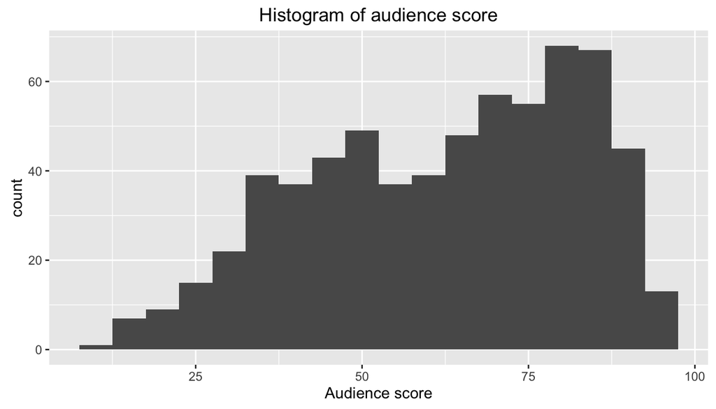

```r
ggplot(data=movies,aes(x=audience_score))+geom_histogram(binwidth=5)+xlab('Audience score') + ggtitle('Histogram of audience score')
```

Figure 1. Distribution of audience score.  
The lowest score is 11.00 and the highest score is 97.00. The mean of score is 62.36 and the median of score is 65.00.

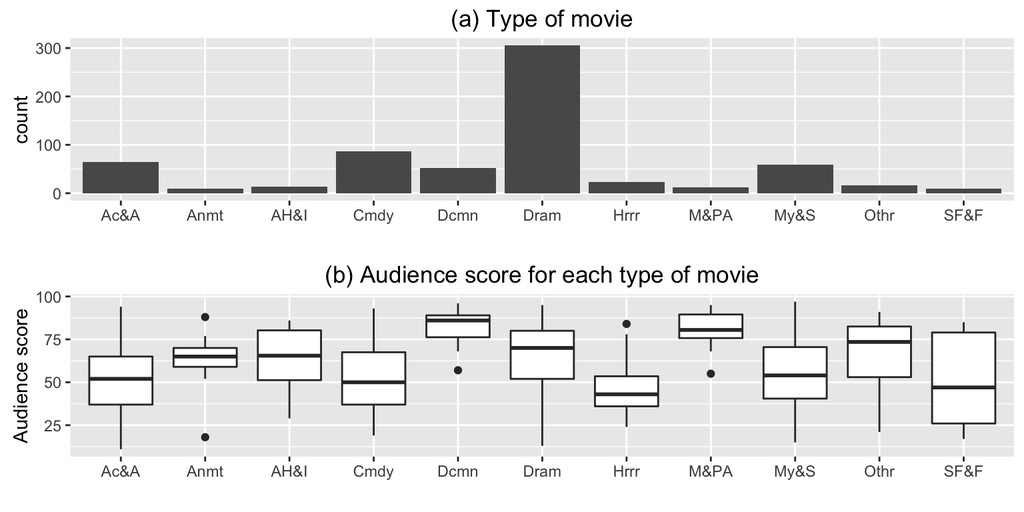

```r
f2a<-ggplot(movies,aes(x=genre))+geom_bar()+xlab('')+ggtitle('(a) Type of movie')+scale_x_discrete(labels = abbreviate)
f2b<-ggplot(movies, aes(x = genre, y = audience_score)) + geom_boxplot() + xlab('')+ylab('Audience score') + ggtitle('(b) Audience score for each type of movie') + scale_x_discrete(labels = abbreviate)
grid.arrange(f2a,f2b,ncol=1)
```

Figure 2 (a) Barplot of movie types. (b) Boxplot of audience score for different movie types. Note that abbreviations of movie types are used in Figure 2(Ac&A: Action&Adventure; Anmt: Animation; AH&I: Art House&International; Cmdy: Comedy; Dcmn: Documentary; Hrrr: Horror; M&PA: Musical&Performing Arts; My&S: Mystery & Suspense; Othr: Other; SF&F: Science Friction & Fantasy).

Figure 2a shows that the number of each type of movie varies a lot from each other. The number of Drama movie is much higher than any other types of movie. Figure 2b shows that the audience score of each type of movie varies from each other, indicating the possible relationship between movie type and movie popularity.

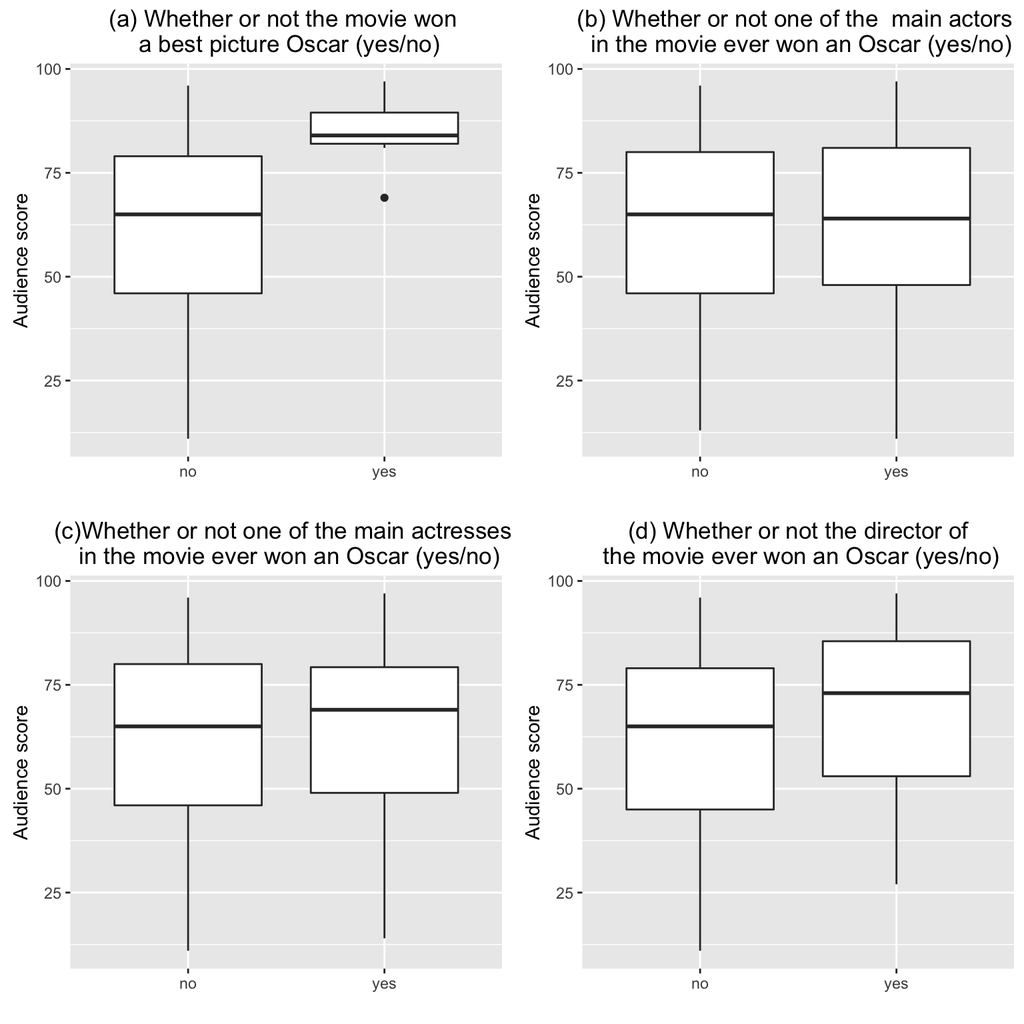

```r
f3a<-ggplot(movies, aes(x = best_pic_win, y = audience_score)) + geom_boxplot() +
  ggtitle('(a) Whether or not the movie won \n a best picture Oscar (yes/no)') +
  ylab('Audience score') + xlab("")
f3b<-ggplot(movies, aes(x = best_actor_win, y = audience_score)) + geom_boxplot() +
  ggtitle('(b) Whether or not one of the  main actors \n in the movie ever won an Oscar (yes/no)') +
  ylab('Audience score') + xlab("")
f3c<-ggplot(movies, aes(x = best_actress_win, y = audience_score)) + geom_boxplot() +
  ggtitle('(c)Whether or not one of the main actresses \n in the movie ever won an Oscar (yes/no)') +
  ylab('Audience score') + xlab("")
f3d<-ggplot(movies, aes(x = best_dir_win, y = audience_score)) + geom_boxplot() +
  ggtitle('(d) Whether or not the director of\n the movie ever won an Oscar (yes/no)') +
  ylab('Audience score') + xlab("")
grid.arrange(f3a,f3b,f3c,f3d,ncol=2)
```

Figure 3. (a) Boxplot of audience score for whether or not the movie won a best picture Oscar. (b) Boxplot of audience score for whether or not the main actors won an Oscar. (c) Boxplot of audience score for whether or not the main actresses won an Oscar. (d) Boxplot of audience score for whether or not the director won an Osacar.

Figure 3 shows that the median audience score for movies that won the best-picture Oscar or for movies with Oscar awarded actresses/director is higher than the median audience score of movies without those. What’s more, the difference between the median audience score of movies winning best-picture Oscar award and the median audience score of the ones without (Fig. 3a) is much larger than the difference in Fig.3c and Fig.3d, indicating the picture quality may play an important role in movie popularity.

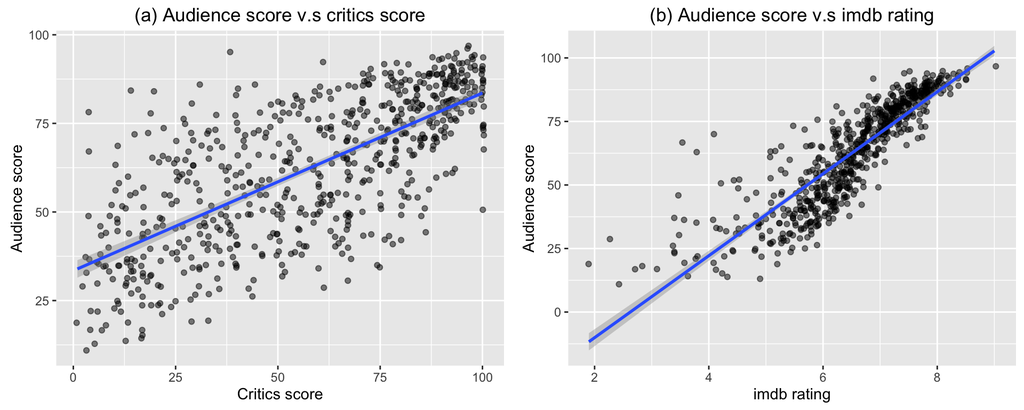

```r
f4a<-ggplot(data=movies,aes(x=critics_score,y=audience_score))+geom_jitter(alpha=0.5)+ggtitle("(a) Audience score v.s critics score") + geom_smooth(method = "lm") + xlab("Critics score") + ylab('Audience score')
f4b<-ggplot(data=movies,aes(x=imdb_rating,y=audience_score))+geom_jitter(alpha=0.5)+ggtitle("(b) Audience score v.s imdb rating") + geom_smooth(method = "lm") + xlab("imdb rating") + ylab('Audience score')
grid.arrange(f4a,f4b,ncol=2)
```

Figure 4. (a) Audience score vs. critics score. (b) Audience score vs. IMDB rating. Black dots are data points. The blue line is the model. The shaded gray area around the line tells us the variability we might expect in our predictions.

Figure 4 shows that audience scores are potisively, linearly and strongly related to critics score/imdb rating, indicating the association between audience score (movie popularity) and critics scores/imdb rating.

```r
movies %>% summarise(cor(imdb_rating, critics_score))
```

```
Source: local data frame [1 x 1]

  cor(imdb_rating, critics_score)
                            (dbl)
1                       0.7650355
```

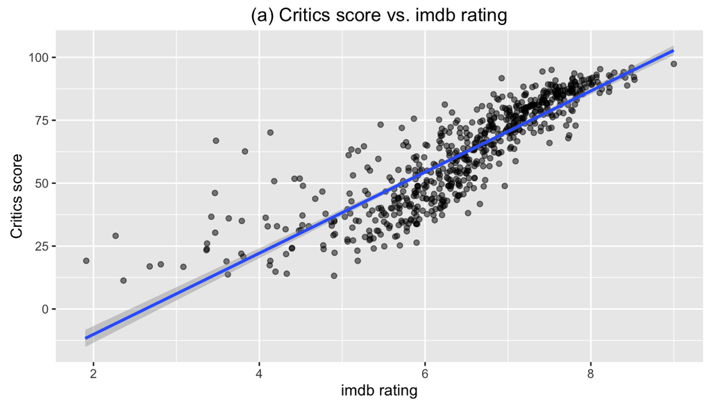

```r
f5<-ggplot(data=movies,aes(x=imdb_rating,y=audience_score))+geom_jitter(alpha=0.5)+ggtitle("(a) Critics score vs. imdb rating") + geom_smooth(method = "lm") + xlab("imdb rating") + ylab('Critics score')
f5
```

## Part 4: Modeling

Firstly, fitting data with the full model.

```r
movies<-filter(movies,!is.na(runtime) & !is.na(critics_score) & !is.na(genre)
             & !is.na(best_pic_win) & !is.na(best_actor_win) & !is.na(best_actress_win)
             & !is.na(best_dir_win))

m1<-lm(audience_score ~ genre + runtime + critics_score + best_pic_win + best_actor_win + best_actress_win + best_dir_win, data=movies)
summary(m1)
```

```
Call:
lm(formula = audience_score ~ genre + runtime + critics_score +
    best_pic_win + best_actor_win + best_actress_win + best_dir_win,
    data = movies)

Residuals:
    Min      1Q  Median      3Q     Max
-36.006  -9.286   0.315   9.441  41.169

Coefficients:
                               Estimate Std. Error t value Pr(>|t|)
(Intercept)                    27.12009    3.76375   7.206 1.65e-12 ***
genreAnimation                  6.18849    5.01631   1.234 0.217782
genreArt House & International  5.73409    4.13645   1.386 0.166163
genreComedy                    -0.43313    2.31466  -0.187 0.851622
genreDocumentary                9.47933    2.82449   3.356 0.000838 ***
genreDrama                      1.92732    1.98343   0.972 0.331567
genreHorror                    -8.29618    3.41550  -2.429 0.015419 *
genreMusical & Performing Arts  9.76812    4.46788   2.186 0.029159 *
genreMystery & Suspense        -4.02438    2.55797  -1.573 0.116156
genreOther                      2.09402    3.94544   0.531 0.595782
genreScience Fiction & Fantasy -6.61934    4.98306  -1.328 0.184535
runtime                         0.07925    0.03241   2.445 0.014745 *
critics_score                   0.44860    0.02202  20.371  < 2e-16 ***
best_pic_winyes                 6.15503    5.74526   1.071 0.284433
best_actor_winyes              -1.13203    1.64849  -0.687 0.492520
best_actress_winyes            -1.62368    1.83069  -0.887 0.375457
best_dir_winyes                -0.41490    2.40725  -0.172 0.863215
---
Signif. codes:  0 '***' 0.001 '**' 0.01 '*' 0.05 '.' 0.1 ' ' 1

Residual standard error: 13.99 on 633 degrees of freedom
Multiple R-squared:  0.534, Adjusted R-squared:  0.5223
F-statistic: 45.34 on 16 and 633 DF,  p-value: < 2.2e-16
```

Variable ‘best_dir_winyes’ has the largest P-value (0.86 > 0.05), so we drop it, refit the model. Note that the categorical variable ‘genre; has multiple levels. Although some of the levels yield much higher p-value than ’best_dir_winyes’ does, we cannot drop those levels and keep other levels. Instead we keep all levels of “genre” since p-values of some of the levels are smaller than 0.05.

```r
m2<-lm(audience_score ~ genre + runtime + critics_score + best_pic_win + best_actor_win + best_actress_win, data=movies)
summary(m2)
```

```
Call:
lm(formula = audience_score ~ genre + runtime + critics_score +
    best_pic_win + best_actor_win + best_actress_win, data = movies)

Residuals:
    Min      1Q  Median      3Q     Max
-36.360  -9.286   0.358   9.472  41.196

Coefficients:
                               Estimate Std. Error t value Pr(>|t|)
(Intercept)                    27.20098    3.73152   7.290  9.3e-13 ***
genreAnimation                  6.20294    5.01177   1.238 0.216295
genreArt House & International  5.76067    4.13041   1.395 0.163596
genreComedy                    -0.42991    2.31282  -0.186 0.852596
genreDocumentary                9.51497    2.81475   3.380 0.000768 ***
genreDrama                      1.93801    1.98095   0.978 0.328286
genreHorror                    -8.29904    3.41285  -2.432 0.015304 *
genreMusical & Performing Arts  9.78084    4.46385   2.191 0.028806 *
genreMystery & Suspense        -4.02400    2.55602  -1.574 0.115911
genreOther                      2.10963    3.94138   0.535 0.592664
genreScience Fiction & Fantasy -6.64031    4.97776  -1.334 0.182684
runtime                         0.07839    0.03200   2.450 0.014562 *
critics_score                   0.44822    0.02189  20.473  < 2e-16 ***
best_pic_winyes                 5.87071    5.49913   1.068 0.286121
best_actor_winyes              -1.14392    1.64578  -0.695 0.487272
best_actress_winyes            -1.62151    1.82924  -0.886 0.375717
---
Signif. codes:  0 '***' 0.001 '**' 0.01 '*' 0.05 '.' 0.1 ' ' 1

Residual standard error: 13.98 on 634 degrees of freedom
Multiple R-squared:  0.534, Adjusted R-squared:  0.523
F-statistic: 48.44 on 15 and 634 DF,  p-value: < 2.2e-16
```

Variable ‘best_actor_winyes’ has the largest P-value (0.487 > 0.05), so we drop it, refit the model. Again, variable ‘genre’ is kept.

```r
m3<-lm(audience_score ~ genre + runtime + critics_score + best_pic_win + best_actress_win, data=movies)
summary(m3)
```

```
Call:
lm(formula = audience_score ~ genre + runtime + critics_score +
    best_pic_win + best_actress_win, data = movies)

Residuals:
    Min      1Q  Median      3Q     Max
-36.074  -9.586   0.351   9.518  41.386

Coefficients:
                               Estimate Std. Error t value Pr(>|t|)
(Intercept)                    27.56905    3.69225   7.467 2.72e-13 ***
genreAnimation                  6.13290    5.00872   1.224 0.221238
genreArt House & International  5.88410    4.12491   1.426 0.154221
genreComedy                    -0.43573    2.31186  -0.188 0.850564
genreDocumentary                9.56785    2.81258   3.402 0.000711 ***
genreDrama                      1.90355    1.97952   0.962 0.336605
genreHorror                    -8.22997    3.41001  -2.413 0.016083 *
genreMusical & Performing Arts  9.86061    4.46056   2.211 0.027418 *
genreMystery & Suspense        -4.16544    2.54687  -1.636 0.102436
genreOther                      2.06767    3.93932   0.525 0.599850
genreScience Fiction & Fantasy -6.52888    4.97315  -1.313 0.189716
runtime                         0.07372    0.03127   2.357 0.018708 *
critics_score                   0.44806    0.02188  20.476  < 2e-16 ***
best_pic_winyes                 5.95609    5.49552   1.084 0.278862
best_actress_winyes            -1.71117    1.82394  -0.938 0.348512
---
Signif. codes:  0 '***' 0.001 '**' 0.01 '*' 0.05 '.' 0.1 ' ' 1

Residual standard error: 13.97 on 635 degrees of freedom
Multiple R-squared:  0.5337,    Adjusted R-squared:  0.5234
F-statistic: 51.91 on 14 and 635 DF,  p-value: < 2.2e-16
```

Variable ‘best_actress_win’ has the largest P-value (0.349 > 0.05), so we drop it, refit the model. Again, variable ‘genre’ is kept.

```r
m4<-lm(audience_score ~ genre + runtime + critics_score + best_pic_win, data=movies)
summary(m4)
```

```
Call:
lm(formula = audience_score ~ genre + runtime + critics_score +
    best_pic_win, data = movies)

Residuals:
    Min      1Q  Median      3Q     Max
-35.997  -9.610   0.579   9.699  41.443

Coefficients:
                               Estimate Std. Error t value Pr(>|t|)
(Intercept)                    28.04422    3.65700   7.669 6.54e-14 ***
genreAnimation                  5.87246    5.00055   1.174 0.240689
genreArt House & International  5.75822    4.12234   1.397 0.162951
genreComedy                    -0.63687    2.30168  -0.277 0.782103
genreDocumentary                9.51819    2.81181   3.385 0.000755 ***
genreDrama                      1.68204    1.96520   0.856 0.392369
genreHorror                    -8.28079    3.40926  -2.429 0.015420 *
genreMusical & Performing Arts  9.91747    4.45973   2.224 0.026514 *
genreMystery & Suspense        -4.41281    2.53294  -1.742 0.081962 .
genreOther                      1.89500    3.93464   0.482 0.630241
genreScience Fiction & Fantasy -6.53820    4.97268  -1.315 0.189043
runtime                         0.06928    0.03091   2.242 0.025335 *
critics_score                   0.44770    0.02188  20.464  < 2e-16 ***
best_pic_winyes                 5.39366    5.46221   0.987 0.323798
---
Signif. codes:  0 '***' 0.001 '**' 0.01 '*' 0.05 '.' 0.1 ' ' 1

Residual standard error: 13.97 on 636 degrees of freedom
Multiple R-squared:  0.533, Adjusted R-squared:  0.5235
F-statistic: 55.84 on 13 and 636 DF,  p-value: < 2.2e-16
```

Variable ‘best_pic_win’ has the largest P-value (0.324 > 0.05), so we drop it, refit the model. Again, variable ‘genre’ is kept.

```r
m5<-lm(audience_score ~ genre + runtime + critics_score, data = movies)
summary(m5)
```

```
Call:
lm(formula = audience_score ~ genre + runtime + critics_score,
    data = movies)

Residuals:
    Min      1Q  Median      3Q     Max
-36.151  -9.586   0.525   9.568  41.424

Coefficients:
                               Estimate Std. Error t value Pr(>|t|)
(Intercept)                    27.37145    3.59290   7.618 9.35e-14 ***
genreAnimation                  5.94345    4.99993   1.189 0.234998
genreArt House & International  5.74324    4.12223   1.393 0.164035
genreComedy                    -0.53569    2.29935  -0.233 0.815856
genreDocumentary                9.45211    2.81096   3.363 0.000818 ***
genreDrama                      1.68250    1.96516   0.856 0.392229
genreHorror                    -8.22215    3.40868  -2.412 0.016142 *
genreMusical & Performing Arts  9.77902    4.45744   2.194 0.028606 *
genreMystery & Suspense        -4.38861    2.53277  -1.733 0.083628 .
genreOther                      1.79864    3.93336   0.457 0.647627
genreScience Fiction & Fantasy -6.54296    4.97258  -1.316 0.188711
runtime                         0.07482    0.03040   2.462 0.014097 *
critics_score                   0.45007    0.02175  20.697  < 2e-16 ***
---
Signif. codes:  0 '***' 0.001 '**' 0.01 '*' 0.05 '.' 0.1 ' ' 1

Residual standard error: 13.97 on 637 degrees of freedom
Multiple R-squared:  0.5323,    Adjusted R-squared:  0.5235
F-statistic: 60.42 on 12 and 637 DF,  p-value: < 2.2e-16
```

Finally, the largest p-value is less than 0.05, then no variable should be dropped. Therefore, all predictors in the current model is our best-fitting model. R-squared equals to 0.532, indicating about 53 precentage of variability in audience score is explained by the model. P-value of the model is 2e-16, so the model as a whole is significant.

Multiple regression methods depend on the following assumptions:  
1.Linear relationship between numerical explanatory variables and response variable.  
2.The residuals are nearly normal.  
3.The variability of the residuals is nearly constant.  
4.The residuals are independent.  
Here, diagnostic plots are used to check each of these assumptions.

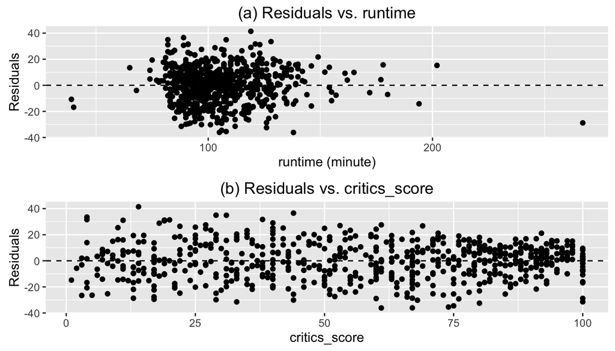

```r
f6a<-ggplot(data=m5,aes(x=movies$runtime,y=.resid)) + geom_point() + ggtitle("(a) Residuals vs. runtime") + xlab("runtime (minute)") + ylab("Residuals") + geom_hline(yintercept = 0, linetype="dashed")
f6b<-ggplot(data=m5,aes(x=movies$critics_score,y=.resid)) + geom_point() + ggtitle("(b) Residuals vs. critics_score") + xlab("critics_score") + ylab("Residuals") + geom_hline(yintercept = 0, linetype="dashed")
grid.arrange(f6a,f6b,ncol=1)
```

Figure 6. (a) Residuals vs. runtime. (b) Residuals vs. critics_score.  
Figure 6 shows that residuals are randomly scattered about zero, indicating that the multiple regression model meets the first condition listed above.

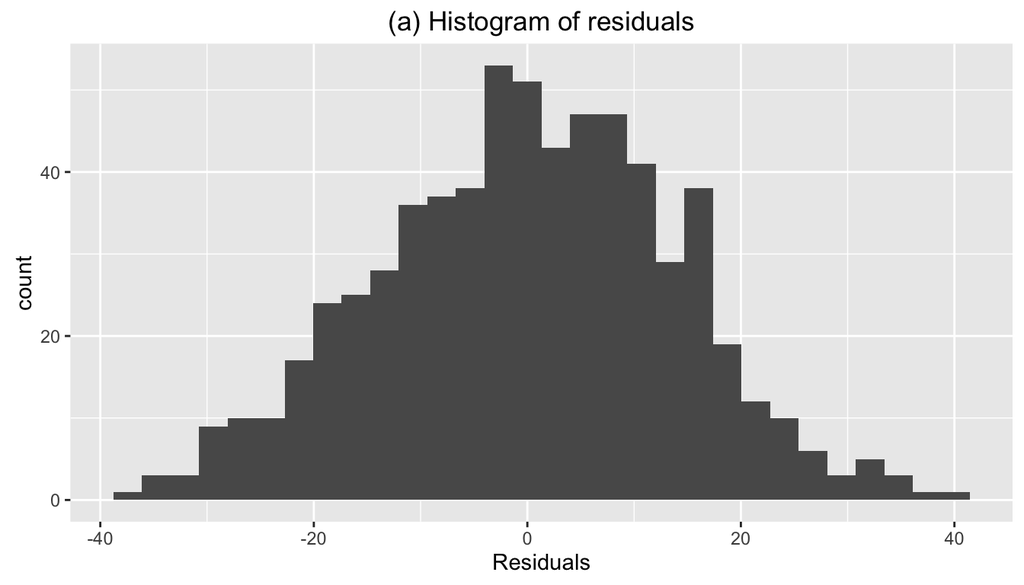

```r
ggplot(data = m5, aes(x=.resid)) + geom_histogram() + xlab("Residuals") + ggtitle("(a) Histogram of residuals")
```

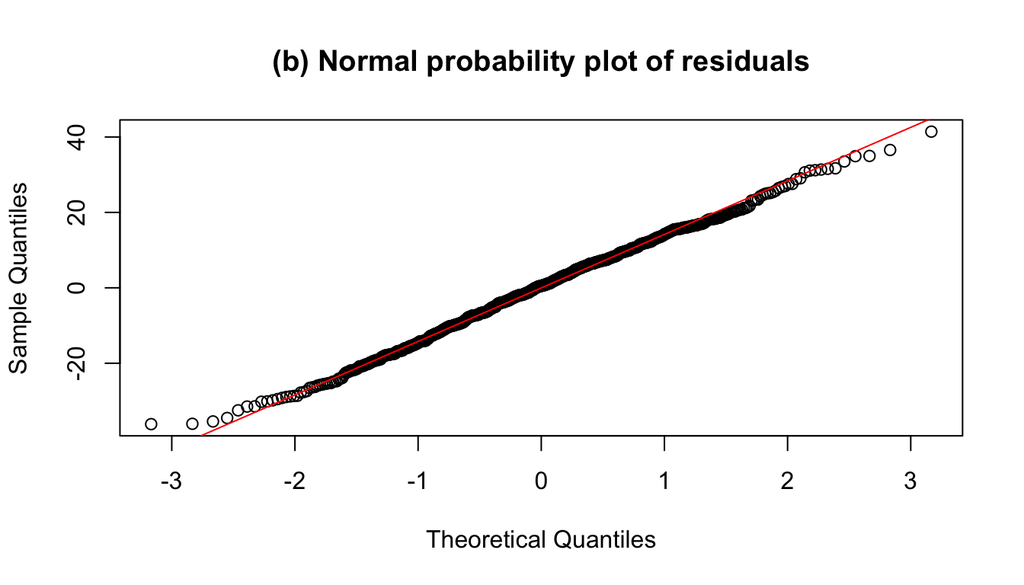

```r
qqnorm(m5$residuals,main = "(b) Normal probability plot of residuals")
qqline(m5$residuals,col="red")
```

Figure 7. (a) Histogram of residuals. (b) Normal probability plot of residuals.  
Figure 7 shows that the residuals are normally distributed. So the multiple regression model meets the second conition listed above.

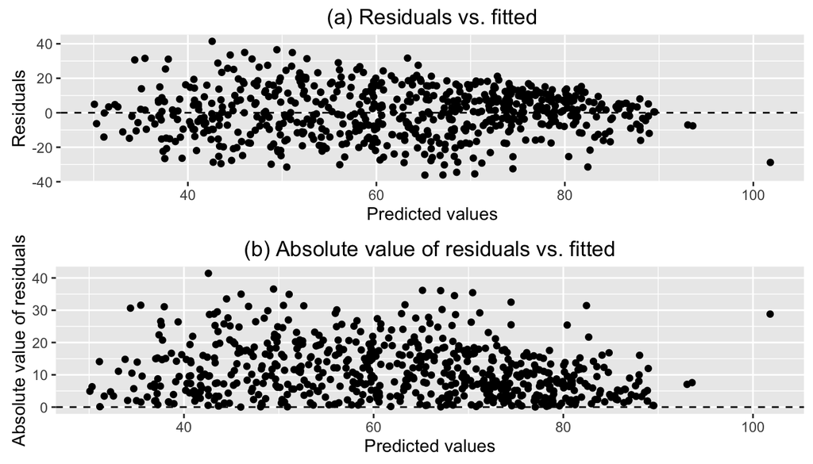

```r
fig8a<-ggplot(data = m5, aes(x=.fitted,y=.resid)) + geom_point() + ggtitle("(a) Residuals vs. fitted") + xlab("Predicted values") + ylab("Residuals") + geom_hline(yintercept = 0, linetype="dashed")
fig8b<-ggplot(data = m5, aes(x=.fitted,y=abs(.resid))) + geom_point() + ggtitle("(b) Absolute value of residuals vs. fitted") + xlab("Predicted values") + ylab("Absolute value of residuals") + geom_hline(yintercept = 0, linetype="dashed")
grid.arrange(fig8a,fig8b,ncol=1)
```

Figure 8. (a) Residuals vs. predicted values. (b) Absolute value of residuals

Figure 8a shows that residuals are randomly scattered in a band with a constant (40) with around zero. We can see a slight fan-shape in Figure 8a. Figure 8b is simply the Figure 8a folded in half. Again, we can see the residuals are randomly scattered above zero with a bandwidth of about 40. The absolute value of residuals slightly decreases as predicted value increase. But the trend is not obvious. We can conclude that the variability of the residual stays nearly constant as the predicted values change, so the constant variability condition is fairly satisfied.

Independent residuals means independent observations. We do not have any information about the order of data collection, so we do not have another diagnostic approch to check the independence condition. However, since the movie data are randomly sampled and the sample size is less than 10% of the movie population, we do not have any reason to assume that the residuals are not independent. Therefore, the residual independent condition is satisfiled.

Therefore, all four conditions are met, indicating the credibility in the best-fit model. The best-fit model shows that all else held constant, for each 1 increase in critics_score the model predicts the audience_score to be higher on average by 0.45; all else held constant, for each 1 minute increase in runtime the model predicts the audience_score to be higher on average by 0.07. All else held constant, the order of the 11 levels of movie genre from lowest predicted audience score to highest predicted audience score is: Horror, Science Fiction & Fantasy, Mystery & Suspense, Comedy, Action and Adventure, Drama, Other, Art House & International, Animation, Documentary, Musical & Performing Arcts.

## Part 5: Prediction

The best-fit model is then used to predict audience_score of the movie called “Me Before You” that released in 2016. The data for this movie come from [IMDB](http://www.imdb.com/) and [Rotten Tomatoes](https://www.rottentomatoes.com). Runtime of this movie is 110 minute, its genre is Drama, critics_score is 59 and the audience_score is 77.

```r
newmovie<-data.frame(genre = "Drama", runtime=110, critics_score=59)
predict(m5,newmovie,interval = "prediction",level = 0.95)
```

```
       fit     lwr      upr
1 63.83837 36.3643 91.31243
```

## Part 6: Conclusion

The metrics of movie popularity is complex. Here, I simpliy use audience score as a proxy for the popularity of a movie. Using multiple linear regression model and a data set collected from [IMDB](http://www.imdb.com/) and [Rotten Tomatoes](https://www.rottentomatoes.com), we find that genre, runtime and critics score are statistically significant predictors of audience score. While whether the movie won a best-picture Oscar or the director/actors/actresses won an Oscar are not significant predictors of audience socre. However, this study only considers a subset of varibales for the initial modeling. Variables such as title, mpaa_rating, studio etc. would also be significant predictors of audience score. Therefore, future study could consider other variables in the model.